# ondeck analytics code and report

Pawandeep Singh

1 Feb 2015

Loading … Necessary packages for the project

```r
library(dplyr)
library(markovchain)
```

```r
library(gridExtra)
library(questionr)
library(ggplot2)
library(forecast)
library(knitr)
library(memisc)
data <- read.csv('/home/pawan/Downloads/OnDeck Analytics Asssignment.csv')
df <- data.frame(data)
summary(df)
```

```
##       as_of_date  days_delinquent_old days_delinquent_new
##  2012-11-01:477   Min.   :  1.00      Min.   :  0.00
##                   1st Qu.:  4.00      1st Qu.:  5.00
##                   Median : 14.00      Median : 22.00
##                   Mean   : 26.66      Mean   : 32.55
##                   3rd Qu.: 38.00      3rd Qu.: 51.00
##                   Max.   :180.00      Max.   :180.00
##
##  new_outstanding_principal_balance initial_loan_amount      fico
##  Min.   :    -0.15                 Min.   :  6000      Min.   :501.0
##  1st Qu.:  7771.34                 1st Qu.: 15000      1st Qu.:591.0
##  Median : 15817.58                 Median : 25000      Median :641.0
##  Mean   : 21406.54                 Mean   : 31448      Mean   :637.3
##  3rd Qu.: 29222.66                 3rd Qu.: 40000      3rd Qu.:683.0
##  Max.   :125000.00                 Max.   :135000      Max.   :806.0
##                                                        NA's   :1
##                          sales_channel__c                  type
##  Direct                          : 74     Loan - New Customer:352
##  FAP: Managed Application Program:370     Loan - Renewal     :125
##  Promontory                      :  1
##  Referral                        : 32
##
##
##
##             current_collection_method      term        lender_payoff
##  ACH Pull                :423         Min.   : 3.000   Min.   :    0
##  Split Funding           : 35         1st Qu.: 6.000   1st Qu.:    0
##  Transfer Account Vendors: 19         Median : 6.000   Median :    0
##                                       Mean   : 8.205   Mean   : 1375
##                                       3rd Qu.:12.000   3rd Qu.:    0
##                                       Max.   :18.000   Max.   :38691
##
##  average_bank_balance__c last_cleared_payment_date
##  Min.   :   357.1        2012-11-01:211
##  1st Qu.:  2967.1        2012-10-31: 38
##  Median :  5717.4        2012-10-30: 17
##  Mean   : 11632.2        2012-10-29: 14
##  3rd Qu.: 11103.0        2012-10-26: 11
##  Max.   :340080.2        2012-10-18:  8
##  NA's   :1               (Other)   :178
```

Creating Factor variables for credit rating.

```r
df$days_delinquent_old_factor <- cut(df$days_delinquent_old, c(0,1,5,10,30,60,180), labels = c("0","1-5","5-10","10-30","30-60","60+"))
df$days_delinquent_new_factor <- cut(df$days_delinquent_new, c(0,1,5,10,30,60,180), labels = c("0","1-5","5-10","10-30","30-60","60+"))
```

#### Feature engineering to create new features using existing features. Designing better features is crucial for a good prediction model.

```r
#Ratio : The ratio of amount due to av. bank balance in account. This give us an idea about the potential to pay the loan.
df$ratio <- df$new_outstanding_principal_balance / df$average_bank_balance__c
#Percent_loan_paid: Fraction of loan paid by the customer.
df$percent_loan_paid <- ((df$initial_loan_amount - df$new_outstanding_principal_balance) / df$initial_loan_amount) * 100
#delinquency_rate:factor by which the delinquency has increased w.r.t to as_of_date
df$delinquency_rate <- df$days_delinquent_new / df$days_delinquent_old
#movement: Tell about loans whose  delinquency has increase or decreased/unchanged
df$movement <- ifelse(df$days_delinquent_new > df$days_delinquent_old, "increase", "same/decreased")
df$last_cleared_payment_date <- as.Date(df$last_cleared_payment_date)
#days_since_last_payment: No of days since the last payment
df$days_since_last_payment <- as.Date("2012-12-1") - df$last_cleared_payment_date
# target: variable made for the prediction task. 1- increase   0- Unchanged/Decreased
df$target <- ifelse(df$movement == "increase", 1, 0)
head(df)
```

```
##   as_of_date days_delinquent_old days_delinquent_new
## 1 2012-11-01                 180                 180
## 2 2012-11-01                   9                   9
## 3 2012-11-01                  56                  75
## 4 2012-11-01                  19                  30
## 5 2012-11-01                  35                  54
## 6 2012-11-01                  12                  26
##   new_outstanding_principal_balance initial_loan_amount fico
## 1                          29383.75               50000  641
## 2                           3200.41               10000  631
## 3                          56207.38               60000  671
## 4                          47496.37               50000  626
## 5                          21012.15               25000  587
## 6                          15423.23               20000  706
##                   sales_channel__c                type
```

[output cut: 34 more lines]

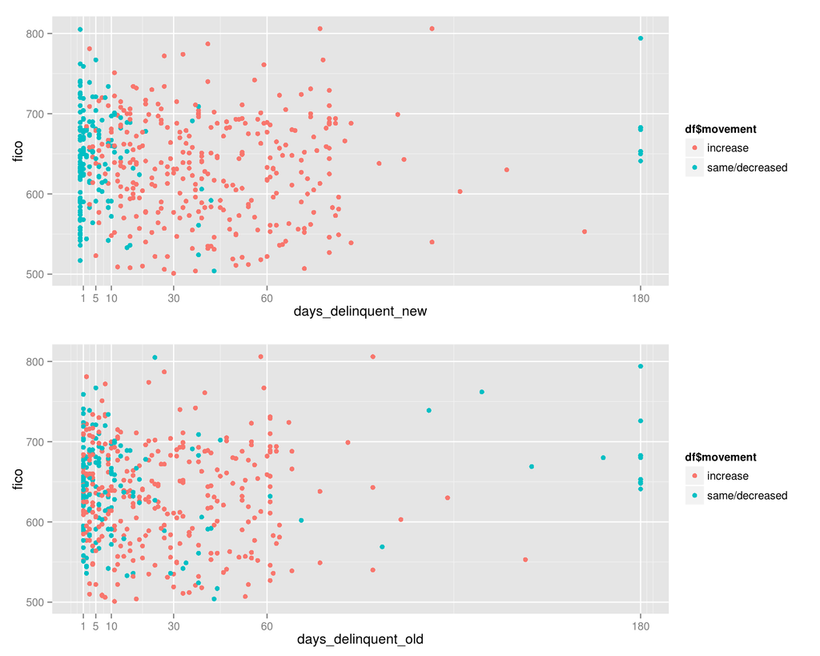

```r
p1 <- ggplot(data = df, aes(x = days_delinquent_new, y = fico)) + geom_point(aes(color=df$movement)) + scale_x_continuous(limits=c(0,180), breaks=c(1,5,10,30,60,180))
p2 <- ggplot(data = df, aes(x = days_delinquent_old, y = fico)) + geom_point(aes(color=df$movement)) + scale_x_continuous(limits=c(0,180), breaks=c(1,5,10,30,60,180))
grid.arrange(p1, p2, ncol = 1)
```

#### This plot we plot percent_loan_paid Vs deliquency_rate. We can see that loans with higher percnet_loan_paid have lower deliquency_rate.In addition to that we see that Direct and FAP have higher deliquency rate, whereas, Referreal and Promontory have lower deliquency rate.

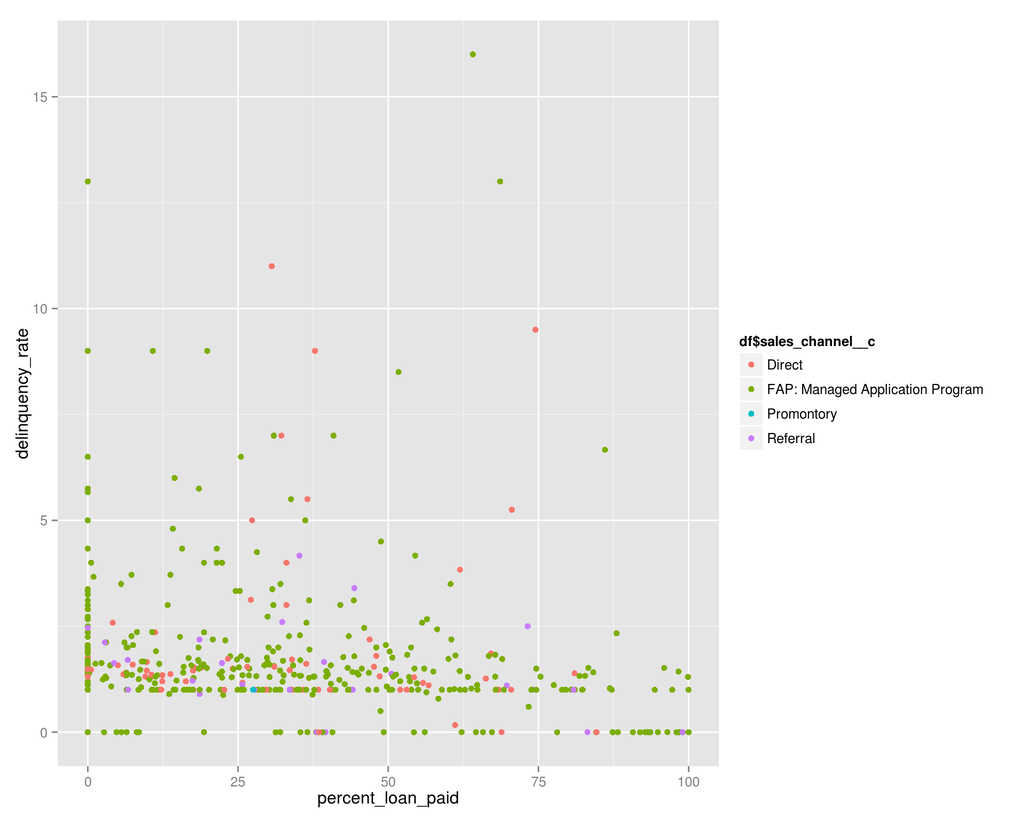

```r
p3 <- ggplot(data = df, aes(x =percent_loan_paid, y = delinquency_rate )) + geom_point(aes(color=df$sales_channel__c))
p3
```

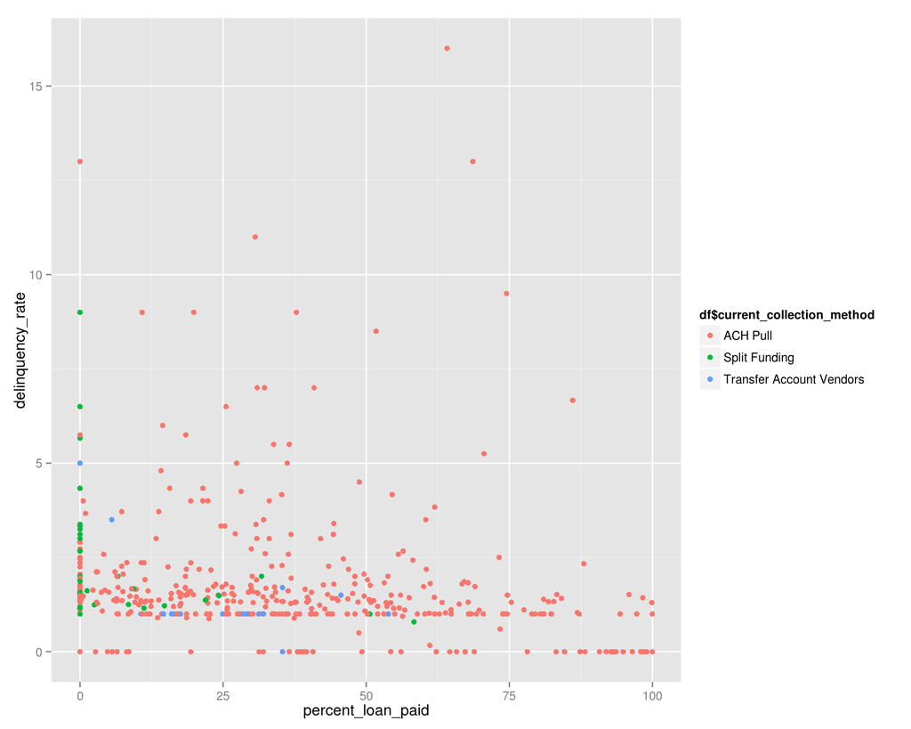

```r
p4 <- ggplot(data = df, aes(x =percent_loan_paid, y = delinquency_rate )) + geom_point(aes(color=df$current_collection_method))
p4
```

#### Important: This is the perfect graph which shows the transition of credit ratings of each loan (fico Vs days_deliquency) with respect to their days_deliqueny_old. This lets us track which loan is underperforming and whose rating has improved. For ex: We see how the ratings from 30-60 blast towards 60+ ratings. And on the other hand we see couple of loan ratings getting improved and moving back towards 0 deliquency. In addition to that we see that slightly higher fico scores have lower deliquency rates.

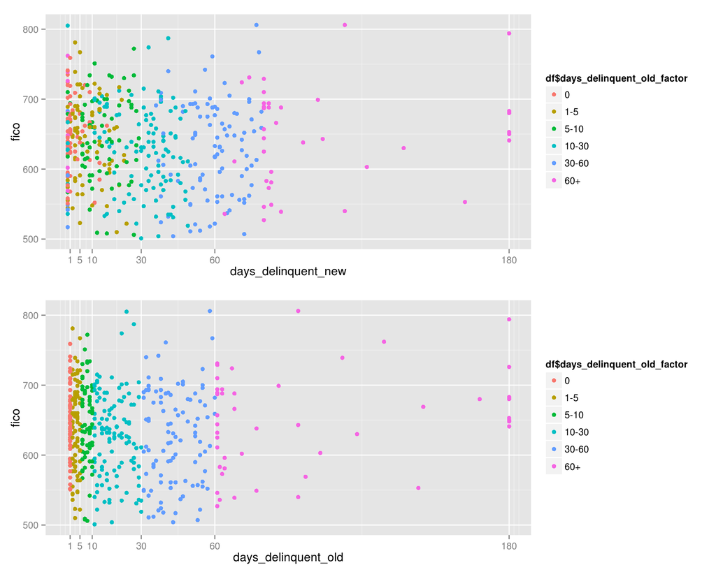

```r
p5 <- ggplot(data = df, aes(x = days_delinquent_new, y = fico)) + geom_point(aes(color=df$days_delinquent_old_factor)) + scale_x_continuous(limits=c(0,180), breaks=c(1,5,10,30,60,180))
p6 <- ggplot(data = df, aes(x = days_delinquent_old, y = fico)) + geom_point(aes(color=df$days_delinquent_old_factor)) + scale_x_continuous(limits=c(0,180), breaks=c(1,5,10,30,60,180))
grid.arrange(p5, p6, ncol = 1)
```

This graph futher shows us the movement of credit ratings across the spectrum for deliquency_rate Vs percent loan paid. But noting certain exceptions. higher loan paid percent have slower deliquency rate.

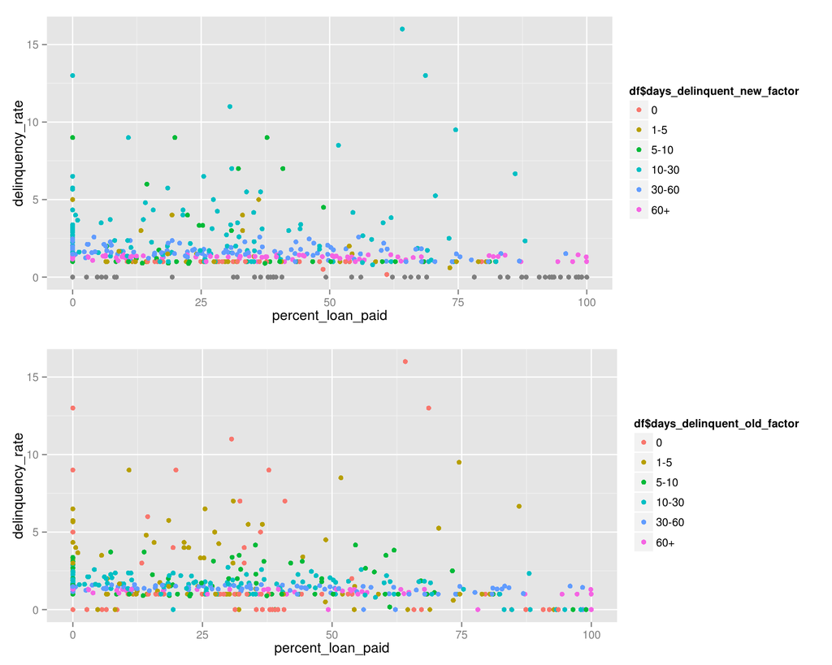

```r
p7 <- ggplot(data = df, aes(x =percent_loan_paid, y = delinquency_rate )) + geom_point(aes(color=df$days_delinquent_new_factor))
p8 <- ggplot(data = df, aes(x =percent_loan_paid, y = delinquency_rate )) + geom_point(aes(color=df$days_delinquent_old_factor))
grid.arrange(p7, p8, ncol=1)
```

```r
transmat <- wtd.table(df$days_delinquent_old_factor, df$days_delinquent_new_factor,na.rm = TRUE)
transmat_prob <- transmat/rowSums(transmat)
transmat_prob
```

```
##                0        1-5       5-10      10-30      30-60        60+
## 0     0.55000000 0.20000000 0.15000000 0.10000000 0.00000000 0.00000000
## 1-5   0.01388889 0.44444444 0.16666667 0.37500000 0.00000000 0.00000000
## 5-10  0.01562500 0.00000000 0.37500000 0.60937500 0.00000000 0.00000000
## 10-30 0.00000000 0.00000000 0.00000000 0.37500000 0.62500000 0.00000000
## 30-60 0.00000000 0.00000000 0.00000000 0.00000000 0.53061224 0.46938776
## 60+   0.00000000 0.00000000 0.00000000 0.00000000 0.00000000 1.00000000
```

```r
transmat_norm <- wtd.table(df$days_delinquent_old_factor, df$days_delinquent_new_factor, weights = df$new_outstanding_principal_balance - mean(df$new_outstanding_principal_balance)/sd(df$new_outstanding_principal_balance),na.rm = TRUE)
transmat_norm_prob <- transmat_norm/rowSums(transmat_norm)

#weighted transition probabilities
transmat_norm_prob
```

```
##                 0         1-5        5-10       10-30       30-60
## 0     0.542772864 0.187066932 0.203422666 0.066737538 0.000000000
## 1-5   0.009989634 0.470919361 0.138479791 0.380611214 0.000000000
## 5-10  0.002859380 0.000000000 0.356476852 0.640663767 0.000000000
## 10-30 0.000000000 0.000000000 0.000000000 0.393239113 0.606760887
## 30-60 0.000000000 0.000000000 0.000000000 0.000000000 0.520886217
## 60+   0.000000000 0.000000000 0.000000000 0.000000000 0.000000000
##               60+
## 0     0.000000000
## 1-5   0.000000000
## 5-10  0.000000000
## 10-30 0.000000000
## 30-60 0.479113783
## 60+   1.000000000
```

#### This is high level breakdown of different parameters w.r.t channel and collection method. Which tells us which channel and collection method is performing better. The reason for showing median along with mean is because median is more robust as compared to mean.

#### Takeaway: we learn Referral channel is the most effective of all other than promontory since it has only one entry. Referral has the lowest principal amount due, lowest delinquent rate, has better bank_balance/ amount_due ratio , highest loan percentage paid. And In terms of collection method ACH perfoms better than its counterpart in termns of percent_loan paid, lower outstanding principle. The following data helps us in making better intuition about the data.

```r
by(df$new_outstanding_principal_balance, df$sales_channel__c, mean)
```

```
## df$sales_channel__c: Direct
## [1] 17549.71
## --------------------------------------------------------
## df$sales_channel__c: FAP: Managed Application Program
## [1] 22796.29
## --------------------------------------------------------
## df$sales_channel__c: Promontory
## [1] 54367.79
## --------------------------------------------------------
## df$sales_channel__c: Referral
## [1] 13226.45
```

```r
by(df$new_outstanding_principal_balance,df$sales_channel__c, median)
```

```
## df$sales_channel__c: Direct
## [1] 12967.4
## --------------------------------------------------------
## df$sales_channel__c: FAP: Managed Application Program
## [1] 17634.18
## --------------------------------------------------------
## df$sales_channel__c: Promontory
## [1] 54367.79
## --------------------------------------------------------
## df$sales_channel__c: Referral
## [1] 8744.035
```

```r
by(df$days_delinquent_old,df$sales_channel__c,mean)
```

```
## df$sales_channel__c: Direct
## [1] 26.10811
## --------------------------------------------------------
## df$sales_channel__c: FAP: Managed Application Program
## [1] 27.71351
## --------------------------------------------------------
## df$sales_channel__c: Promontory
## [1] 3
## --------------------------------------------------------
## df$sales_channel__c: Referral
## [1] 16.4375
```

```r
by(df$days_delinquent_old,df$sales_channel__c,median)
```

```
## df$sales_channel__c: Direct
## [1] 14
## --------------------------------------------------------
## df$sales_channel__c: FAP: Managed Application Program
## [1] 15
## --------------------------------------------------------
## df$sales_channel__c: Promontory
## [1] 3
## --------------------------------------------------------
## df$sales_channel__c: Referral
## [1] 10
```

```r
by(df$days_delinquent_new,df$sales_channel__c,mean)
```

```
## df$sales_channel__c: Direct
## [1] 36.40541
## --------------------------------------------------------
## df$sales_channel__c: FAP: Managed Application Program
## [1] 32.66216
## --------------------------------------------------------
## df$sales_channel__c: Promontory
## [1] 3
## --------------------------------------------------------
## df$sales_channel__c: Referral
## [1] 23.25
```

```r
by(df$days_delinquent_new,df$sales_channel__c,median)
```

```
## df$sales_channel__c: Direct
## [1] 24.5
## --------------------------------------------------------
## df$sales_channel__c: FAP: Managed Application Program
## [1] 21
## --------------------------------------------------------
## df$sales_channel__c: Promontory
## [1] 3
## --------------------------------------------------------
## df$sales_channel__c: Referral
## [1] 18.5
```

```r
by(df$ratio,df$sales_channel__c,mean)
```

```
## df$sales_channel__c: Direct
## [1] 2.627341
## --------------------------------------------------------
## df$sales_channel__c: FAP: Managed Application Program
## [1] NA
## --------------------------------------------------------
## df$sales_channel__c: Promontory
## [1] 6.605857
## --------------------------------------------------------
## df$sales_channel__c: Referral
## [1] 2.508644
```

```r
by(df$ratio,df$sales_channel__c,median)
```

```
## df$sales_channel__c: Direct
## [1] 2.309506
## --------------------------------------------------------
## df$sales_channel__c: FAP: Managed Application Program
## [1] NA
## --------------------------------------------------------
## df$sales_channel__c: Promontory
## [1] 6.605857
## --------------------------------------------------------
## df$sales_channel__c: Referral
## [1] 2.045726
```

```r
by(df$ratio, df$current_collection_method, mean)
```

```
## df$current_collection_method: ACH Pull
## [1] NA
## --------------------------------------------------------
## df$current_collection_method: Split Funding
## [1] 12.89097
## --------------------------------------------------------
## df$current_collection_method: Transfer Account Vendors
## [1] 7.939639
```

```r
by(df$ratio, df$current_collection_method, median)
```

```
## df$current_collection_method: ACH Pull
## [1] NA
## --------------------------------------------------------
## df$current_collection_method: Split Funding
## [1] 9.023223
## --------------------------------------------------------
## df$current_collection_method: Transfer Account Vendors
## [1] 6.740329
```

```r
by(df$new_outstanding_principal_balance, df$current_collection_method, mean)
```

```
## df$current_collection_method: ACH Pull
## [1] 19577.79
## --------------------------------------------------------
## df$current_collection_method: Split Funding
## [1] 40807.87
## --------------------------------------------------------
## df$current_collection_method: Transfer Account Vendors
## [1] 26381.16
```

```r
by(df$new_outstanding_principal_balance, df$current_collection_method, median)
```

```
## df$current_collection_method: ACH Pull
## [1] 14916.78
## --------------------------------------------------------
## df$current_collection_method: Split Funding
## [1] 35000
## --------------------------------------------------------
## df$current_collection_method: Transfer Account Vendors
## [1] 21354.44
```

```r
by(df$average_bank_balance__c, df$current_collection_method, mean)
```

```
## df$current_collection_method: ACH Pull
## [1] NA
## --------------------------------------------------------
## df$current_collection_method: Split Funding
## [1] 5506.167
## --------------------------------------------------------
## df$current_collection_method: Transfer Account Vendors
## [1] 4975.557
```

```r
by(df$average_bank_balance__c, df$current_collection_method, median)
```

```
## df$current_collection_method: ACH Pull
## [1] NA
## --------------------------------------------------------
## df$current_collection_method: Split Funding
## [1] 3694.53
## --------------------------------------------------------
## df$current_collection_method: Transfer Account Vendors
## [1] 3681.45
```

```r
by(df$percent_loan_paid, df$sales_channel__c, mean)
```

```
## df$sales_channel__c: Direct
## [1] 30.5145
## --------------------------------------------------------
## df$sales_channel__c: FAP: Managed Application Program
## [1] 35.00342
## --------------------------------------------------------
## df$sales_channel__c: Promontory
## [1] 27.50961
## --------------------------------------------------------
## df$sales_channel__c: Referral
## [1] 35.19705
```

```r
by(df$percent_loan_paid, df$sales_channel__c, median)
```

```
## df$sales_channel__c: Direct
## [1] 28.49312
## --------------------------------------------------------
## df$sales_channel__c: FAP: Managed Application Program
## [1] 30.49383
## --------------------------------------------------------
## df$sales_channel__c: Promontory
## [1] 27.50961
## --------------------------------------------------------
## df$sales_channel__c: Referral
## [1] 32.9775
```

```r
by(df$percent_loan_paid, df$current_collection_method, mean)
```

```
## df$current_collection_method: ACH Pull
## [1] 36.80419
## --------------------------------------------------------
## df$current_collection_method: Split Funding
## [1] 6.886746
## --------------------------------------------------------
## df$current_collection_method: Transfer Account Vendors
## [1] 29.15494
```

```r
by(df$percent_loan_paid, df$current_collection_method, median)
```

```
## df$current_collection_method: ACH Pull
## [1] 32.41992
## --------------------------------------------------------
## df$current_collection_method: Split Funding
## [1] 0
## --------------------------------------------------------
## df$current_collection_method: Transfer Account Vendors
## [1] 29.08867
```

```r
by(df$delinquency_rate, df$sales_channel__c, mean)
```

```
## df$sales_channel__c: Direct
## [1] 2.009209
## --------------------------------------------------------
## df$sales_channel__c: FAP: Managed Application Program
## [1] 1.760655
## --------------------------------------------------------
## df$sales_channel__c: Promontory
## [1] 1
## --------------------------------------------------------
## df$sales_channel__c: Referral
## [1] 1.483023
```

```r
by(df$delinquency_rate, df$sales_channel__c, median)
```

```
## df$sales_channel__c: Direct
## [1] 1.428318
## --------------------------------------------------------
## df$sales_channel__c: FAP: Managed Application Program
## [1] 1.349003
## --------------------------------------------------------
## df$sales_channel__c: Promontory
## [1] 1
## --------------------------------------------------------
## df$sales_channel__c: Referral
## [1] 1.166557
```

```r
by(df$delinquency_rate, df$current_collection_method, mean)
```

```
## df$current_collection_method: ACH Pull
## [1] 1.752674
## --------------------------------------------------------
## df$current_collection_method: Split Funding
## [1] 2.357138
## --------------------------------------------------------
## df$current_collection_method: Transfer Account Vendors
## [1] 1.3
```

```r
by(df$delinquency_rate, df$current_collection_method, median)
```

```
## df$current_collection_method: ACH Pull
## [1] 1.351852
## --------------------------------------------------------
## df$current_collection_method: Split Funding
## [1] 1.666667
## --------------------------------------------------------
## df$current_collection_method: Transfer Account Vendors
## [1] 1
```

#### I implemented a logistic regression model. Logistic regression is good for predicting outcomes with two states, i.t the odds where the ratings will improve or degrade.

#### This is the model trained on whole data and we add vairable one at a time and compare whether they improve the likelihood of the model or not.Following we have the implementation for chekcing the effectiveness of the model. Here we see that “percent_loan_paid”, “days_since_last_payment” and “loan type” are statistically significant with p values < 0.05. These featues are the driving force behind the model accuracy and can accurately predict the likelihood of ratings going up or down.

```r
m1 <- glm(target ~ ratio, data = df, family = "binomial")
m2 <- update(m1,  ~ . + percent_loan_paid)
m3 <- update(m2, ~ . + lender_payoff)
m4 <- update(m3, ~ . + fico)
m5 <- update(m4, ~ . + sales_channel__c)
m6 <- update(m5, ~ . + type)
m7 <- update(m6, ~ . + days_since_last_payment)
mtable(m1, m2, m3,m5,m5,m6,m7)
```

```
##
## Calls:
## m1: glm(formula = target ~ ratio, family = "binomial", data = df)
## m2: glm(formula = target ~ ratio + percent_loan_paid, family = "binomial",
##     data = df)
## m3: glm(formula = target ~ ratio + percent_loan_paid + lender_payoff,
##     family = "binomial", data = df)
## m5: glm(formula = target ~ ratio + percent_loan_paid + lender_payoff +
##     fico + sales_channel__c, family = "binomial", data = df)
## m5: glm(formula = target ~ ratio + percent_loan_paid + lender_payoff +
##     fico + sales_channel__c, family = "binomial", data = df)
## m6: glm(formula = target ~ ratio + percent_loan_paid + lender_payoff +
##     fico + sales_channel__c + type, family = "binomial", data = df)
## m7: glm(formula = target ~ ratio + percent_loan_paid + lender_payoff +
##     fico + sales_channel__c + type + days_since_last_payment,
##     family = "binomial", data = df)
##
## =======================================================================================================================================
##                                                         m1          m2          m3          m5          m5          m6          m7
## ---------------------------------------------------------------------------------------------------------------------------------------
## (Intercept)                                           0.481***    1.907***    1.886***     3.894***    3.894***    3.862***    3.940***
##                                                      (0.131)     (0.227)     (0.230)      (1.146)     (1.146)     (1.157)     (1.169)
## ratio                                                 0.047      -0.025      -0.026       -0.021      -0.021      -0.022      -0.020
##                                                      (0.025)     (0.019)     (0.019)      (0.020)     (0.020)     (0.020)     (0.020)
## percent_loan_paid                                                -0.031***   -0.031***    -0.030***   -0.030***   -0.031***   -0.033***
##                                                                  (0.004)     (0.004)      (0.004)     (0.004)     (0.004)     (0.004)
## lender_payoff                                                                 0.000        0.000       0.000       0.000      -0.000
##                                                                              (0.000)      (0.000)     (0.000)     (0.000)     (0.000)
## fico                                                                                      -0.003      -0.003      -0.002      -0.003
##                                                                                           (0.002)     (0.002)     (0.002)     (0.002)
## sales_channel__cFAP x  Managed Application Program                                        -0.256      -0.256      -0.279      -0.313
##                                                                                           (0.307)     (0.307)     (0.310)     (0.314)
## sales_channel__c: Promontory/Direct                                                      -14.624     -14.624     -14.282     -14.236
##                                                                                         (535.411)   (535.411)   (535.411)   (535.411)
## sales_channel__c: Referral/Direct                                                         -0.742      -0.742      -0.772      -0.766
##                                                                                           (0.475)     (0.475)     (0.480)     (0.487)
## type: Loan - Renewal/Loan - New Customer                                                                          -0.530*     -0.549*
##                                                                                                                   (0.239)     (0.240)
## days_since_last_payment                                                                                                        0.004*
##                                                                                                                               (0.002)
## ---------------------------------------------------------------------------------------------------------------------------------------
## Aldrich-Nelson R-sq.                                    0.010       0.126       0.126       0.136       0.136       0.143       0.151
## McFadden R-sq.                                          0.008       0.112       0.112       0.123       0.123       0.131       0.139
## Cox-Snell R-sq.                                         0.010       0.134       0.134       0.145       0.145       0.154       0.163
## Nagelkerke R-sq.                                        0.014       0.185       0.186       0.201       0.201       0.214       0.226
## phi                                                     1.000       1.000       1.000       1.000       1.000       1.000       1.000
## Likelihood-ratio                                        4.702      68.374      68.665      74.633      74.633      79.539      84.515
## p                                                       0.030       0.000       0.000       0.000       0.000       0.000       0.000
## Log-likelihood                                       -302.888    -271.052    -270.906    -266.843    -266.843    -264.390    -261.902
## Deviance                                              605.775     542.104     541.813     533.685     533.685     528.779     523.803
## AIC                                                   609.775     548.104     549.813     549.685     549.685     546.779     543.803
## BIC                                                   618.106     560.601     566.474     582.992     582.992     584.249     585.437
## N                                                     476         476         476         475         475         475         475
## =======================================================================================================================================
```

#### Here we will train the model using around 90% of the data and will predict the reamaining testing data using the trained model.

```r
training <- df[1:420,]
testing <- df[421:477,]
head(testing)
```

```
##     as_of_date days_delinquent_old days_delinquent_new
## 421 2012-11-01                   8                   8
## 422 2012-11-01                   6                  12
## 423 2012-11-01                   2                   9
## 424 2012-11-01                  97                   0
## 425 2012-11-01                  12                  31
## 426 2012-11-01                   1                   5
##     new_outstanding_principal_balance initial_loan_amount fico
## 421                          11327.38               20000  637
## 422                           6828.16               10000  698
## 423                           9217.27               18000  660
## 424                             -0.15               20000  569
## 425                          47705.36               75000  688
## 426                          75000.00               75000  638
##                     sales_channel__c                type
```

[output cut: 34 more lines]

```r
ma <- glm(target ~ ratio, data = training, family = "binomial")
mb <- update(ma,  ~ . + percent_loan_paid)
mc <- update(mb, ~ . + lender_payoff)
md <- update(mc, ~ . + fico)
me <- update(md, ~ . + sales_channel__c)
mf <- update(me, ~ . + type)
mg <- update(mf, ~ . + days_since_last_payment)
mtable(ma, mb, mc,md,me,mf,mg)
```

```
##
## Calls:
## ma: glm(formula = target ~ ratio, family = "binomial", data = training)
## mb: glm(formula = target ~ ratio + percent_loan_paid, family = "binomial",
##     data = training)
## mc: glm(formula = target ~ ratio + percent_loan_paid + lender_payoff,
##     family = "binomial", data = training)
## md: glm(formula = target ~ ratio + percent_loan_paid + lender_payoff +
##     fico, family = "binomial", data = training)
## me: glm(formula = target ~ ratio + percent_loan_paid + lender_payoff +
##     fico + sales_channel__c, family = "binomial", data = training)
## mf: glm(formula = target ~ ratio + percent_loan_paid + lender_payoff +
##     fico + sales_channel__c + type, family = "binomial", data = training)
## mg: glm(formula = target ~ ratio + percent_loan_paid + lender_payoff +
##     fico + sales_channel__c + type + days_since_last_payment,
##     family = "binomial", data = training)
##
## =======================================================================================================================================
##                                                         ma          mb          mc          md          me          mf          mg
## ---------------------------------------------------------------------------------------------------------------------------------------
## (Intercept)                                           0.473***    1.961***    1.938***    3.714**      3.893**     3.849**     3.971**
##                                                      (0.140)     (0.254)     (0.256)     (1.192)      (1.215)     (1.223)     (1.241)
## ratio                                                 0.041      -0.040      -0.041      -0.038       -0.037      -0.036      -0.033
##                                                      (0.025)     (0.024)     (0.024)     (0.024)      (0.024)     (0.024)     (0.024)
## percent_loan_paid                                                -0.032***   -0.032***   -0.031***    -0.031***   -0.032***   -0.034***
##                                                                  (0.004)     (0.004)     (0.005)      (0.005)     (0.005)     (0.005)
## lender_payoff                                                                 0.000       0.000        0.000       0.000       0.000
##                                                                              (0.000)     (0.000)      (0.000)     (0.000)     (0.000)
## fico                                                                                     -0.003       -0.003      -0.002      -0.003
##                                                                                          (0.002)      (0.002)     (0.002)     (0.002)
## sales_channel__cFAP x  Managed Application Program                                                    -0.225      -0.241      -0.281
##                                                                                                       (0.326)     (0.328)     (0.332)
## sales_channel__c: Promontory/Direct                                                                  -14.526     -14.262     -14.219
##                                                                                                     (535.411)   (535.411)   (535.411)
## sales_channel__c: Referral/Direct                                                                     -0.759      -0.770      -0.756
##                                                                                                       (0.492)     (0.495)     (0.503)
## type: Loan - Renewal/Loan - New Customer                                                                          -0.408      -0.404
##                                                                                                                   (0.256)     (0.259)
## days_since_last_payment                                                                                                        0.005*
##                                                                                                                               (0.002)
## ---------------------------------------------------------------------------------------------------------------------------------------
## Aldrich-Nelson R-sq.                                    0.007       0.129       0.129       0.131       0.139       0.144       0.154
## McFadden R-sq.                                          0.006       0.115       0.115       0.117       0.126       0.131       0.142
## Cox-Snell R-sq.                                         0.007       0.137       0.138       0.140       0.150       0.155       0.167
## Nagelkerke R-sq.                                        0.010       0.189       0.191       0.194       0.207       0.214       0.230
## phi                                                     1.000       1.000       1.000       1.000       1.000       1.000       1.000
## Likelihood-ratio                                        3.138      61.886      62.267      63.134      67.763      70.276      76.292
## p                                                       0.076       0.000       0.000       0.000       0.000       0.000       0.000
## Log-likelihood                                       -268.676    -239.301    -239.111    -237.614    -235.300    -234.043    -231.035
## Deviance                                              537.351     478.602     478.222     475.228     470.599     468.086     462.070
## AIC                                                   541.351     484.602     486.222     485.228     486.599     486.086     482.070
## BIC                                                   549.427     496.716     502.373     505.406     518.883     522.406     522.425
## N                                                     419         419         419         418         418         418         418
## =======================================================================================================================================
```

Testign part

#### We creating a predict variable in testing data frame and will use the target to check our prediction.

```r
testing$predict <- predict(mg, newdata=testing, type= "response")
```

#### If the prediction probaliity is greater then 0.33, we make the prediction to 1 i.e the rating increased and 0 otherwise.

```r
testing$predict <- ifelse(testing$predict > 0.33, 1, 0 )
testing[,c('target', 'predict')]
```

```
##     target predict
## 421      0       1
## 422      1       1
## 423      1       1
## 424      0       0
## 425      1       1
## 426      1       1
## 427      1       1
## 428      0       0
## 429      1       1
## 430      0       1
## 431      1       1
## 432      1       1
## 433      1       1
## 434      1       1
```

[output cut: 43 more lines]

#### The accuracy function calculates the mean error. and it is around 0.228. which indirectly tell us that the accuracy is around 77%.

```r
acc <- accuracy(testing$predict, testing$target)
acc
```

```
##                  ME      RMSE       MAE  MPE MAPE
## Test set -0.2280702 0.4775669 0.2280702 -Inf  Inf
```

```r
confusionmatrix <- table(testing$predict, testing$target)
confusionmatrix
```

```
##
##      0  1
##   0  4  0
##   1 13 40
```

#### To summarize, we see that percent_loan_paid, days_since_last_payment and loan type are statistically significant in predicing the target variable i.e (whether the credit ratings increased or not). In conjunctin with logistic regresssion we get an accuracy of around 77%. Which is pretty decent given the size of data. More data, and experminting with additional techniqus such as lasso, elastic nets and advanced techniques such as CNN and RNN could further help us create a better model.